# Financial ML Tuning and Model Selection

This notebook performs focused second-round hyperparameter tuning for the supervised PaySim V1 fraud detection models:

1. Logistic Regression
2. Random Forest
3. XGBoost

The goal is to tune candidate supervised model families and select the final supervised ML model using validation performance only. The test set is not used for model selection.

**Important:** This notebook does not implement Autoencoder anomaly detection, risk scoring, Streamlit, API, or Docker.

## 1. Import Libraries and Project Functions

Most reusable logic comes from `src/`, including preprocessing, model pipelines, tuning utilities, and evaluation helpers.

```python
from pathlib import Path
import sys
import importlib

import joblib
import pandas as pd
import matplotlib.pyplot as plt
from sklearn.base import clone

pd.set_option("display.max_columns", None)
pd.set_option("display.float_format", "{:.4f}".format)
plt.style.use("default")
```

```python
PROJECT_ROOT = Path.cwd()

if PROJECT_ROOT.name == "notebooks":
    PROJECT_ROOT = PROJECT_ROOT.parent

if not (PROJECT_ROOT / "src").exists():
    PROJECT_ROOT = PROJECT_ROOT.parent

if str(PROJECT_ROOT) not in sys.path:
    sys.path.append(str(PROJECT_ROOT))

import src.preprocessing as preprocessing
import src.model as model_utils
import src.model_selection as model_selection_utils
import src.evaluate as evaluate_utils

# Reload project modules so notebook runs see recent local src/ edits.
preprocessing = importlib.reload(preprocessing)
model_utils = importlib.reload(model_utils)
model_selection_utils = importlib.reload(model_selection_utils)
evaluate_utils = importlib.reload(evaluate_utils)

load_paysim_data = preprocessing.load_paysim_data
create_engineered_features = preprocessing.create_engineered_features
prepare_features_and_target = preprocessing.prepare_features_and_target
create_train_test_split = preprocessing.create_train_test_split
sample_training_data = preprocessing.sample_training_data
get_feature_columns = preprocessing.get_feature_columns

get_baseline_models = model_utils.get_baseline_models

get_tuning_param_distributions = model_selection_utils.get_tuning_param_distributions
tune_candidate_models = model_selection_utils.tune_candidate_models
evaluate_tuned_models = model_selection_utils.evaluate_tuned_models
select_best_tuned_model = model_selection_utils.select_best_tuned_model
get_best_estimator = model_selection_utils.get_best_estimator
evaluate_binary_classifier = evaluate_utils.evaluate_binary_classifier

DATA_PATH = PROJECT_ROOT / "data" / "raw" / "financial" / "paysim.csv"
REPORTS_DIR = PROJECT_ROOT / "reports"
TUNED_RESULTS_PATH = REPORTS_DIR / "tuned_model_comparison.csv"
FINAL_TEST_METRICS_PATH = REPORTS_DIR / "final_supervised_test_evaluation.csv"
SELECTED_MODEL_PATH = PROJECT_ROOT / "models" / "ml" / "selected_model.pkl"
FINAL_SUPERVISED_MODEL_PATH = PROJECT_ROOT / "models" / "ml" / "final_supervised_model.pkl"

print(f"Project root: {PROJECT_ROOT}")
print(f"Dataset path: {DATA_PATH}")
print(f"Tuned results path: {TUNED_RESULTS_PATH}")
print(f"Final supervised test metrics path: {FINAL_TEST_METRICS_PATH}")
print(f"Selected model path: {SELECTED_MODEL_PATH}")
print(f"Final supervised model path: {FINAL_SUPERVISED_MODEL_PATH}")
```

```
Project root: d:\cs s1 26\基于深度学习的交易欺诈检测与智能风控系统\transaction-fraud-detection-system
Dataset path: d:\cs s1 26\基于深度学习的交易欺诈检测与智能风控系统\transaction-fraud-detection-system\data\raw\financial\paysim.csv
Tuned results path: d:\cs s1 26\基于深度学习的交易欺诈检测与智能风控系统\transaction-fraud-detection-system\reports\tuned_model_comparison.csv
Final supervised test metrics path: d:\cs s1 26\基于深度学习的交易欺诈检测与智能风控系统\transaction-fraud-detection-system\reports\final_supervised_test_evaluation.csv
Selected model path: d:\cs s1 26\基于深度学习的交易欺诈检测与智能风控系统\transaction-fraud-detection-system\models\ml\selected_model.pkl
Final supervised model path: d:\cs s1 26\基于深度学习的交易欺诈检测与智能风控系统\transaction-fraud-detection-system\models\ml\final_supervised_model.pkl
```

## 2. Load PaySim Data

The full PaySim dataset is loaded from the local project folder. No data is downloaded in this notebook.

```python
df = load_paysim_data(DATA_PATH)

print(f"Dataset shape: {df.shape}")
df.head()
```

```
Dataset shape: (6362620, 11)
```

|  | step | type | amount | nameOrig | oldbalanceOrg | newbalanceOrig | nameDest | oldbalanceDest | newbalanceDest | isFraud | isFlaggedFraud |
| --- | --- | --- | --- | --- | --- | --- | --- | --- | --- | --- | --- |
| 0 | 1 | PAYMENT | 9839.6400 | C1231006815 | 170136.0000 | 160296.3600 | M1979787155 | 0.0000 | 0.0000 | 0 | 0 |
| 1 | 1 | PAYMENT | 1864.2800 | C1666544295 | 21249.0000 | 19384.7200 | M2044282225 | 0.0000 | 0.0000 | 0 | 0 |
| 2 | 1 | TRANSFER | 181.0000 | C1305486145 | 181.0000 | 0.0000 | C553264065 | 0.0000 | 0.0000 | 1 | 0 |
| 3 | 1 | CASH_OUT | 181.0000 | C840083671 | 181.0000 | 0.0000 | C38997010 | 21182.0000 | 0.0000 | 1 | 0 |
| 4 | 1 | PAYMENT | 11668.1400 | C2048537720 | 41554.0000 | 29885.8600 | M1230701703 | 0.0000 | 0.0000 | 0 | 0 |

```python
pd.DataFrame({
    "count": df["isFraud"].value_counts().sort_index(),
    "percent": df["isFraud"].value_counts(normalize=True).sort_index() * 100,
})
```

| isFraud | count | percent |
| --- | --- | --- |
| 0 | 6354407 | 99.8709 |
| 1 | 8213 | 0.1291 |

**Observation:** Fraud is highly imbalanced in PaySim. For tuning, we optimize `average_precision` because PR-AUC is more informative than accuracy for rare fraud detection.

## Data Preparation Strategy

This notebook reuses the same preprocessing, train/validation/test split, and training-only sampling strategy as notebook 02. The steps are repeated here so notebook 03 can run independently and so tuned model results are comparable to the baseline results.

## 3. Feature Engineering

We reuse the same engineered features from the baseline notebook. The target column `isFraud`, ID-like columns `nameOrig` and `nameDest`, and rule-based `isFlaggedFraud` are excluded from model features by default.

```python
features_df = create_engineered_features(df)
X, y = prepare_features_and_target(features_df, use_is_flagged_fraud=False)

print(f"X shape: {X.shape}")
print(f"y shape: {y.shape}")
```

```
X shape: (6362620, 16)
y shape: (6362620,)
```

## 4. Train / Validation / Test Split

The split logic matches notebook 02:

- `X_train_full` / `y_train_full`: original full training split before sampling
- `X_val` / `y_val`: untouched validation set for tuned model comparison
- `X_test` / `y_test`: untouched holdout test set
- validation is used for model tuning comparison
- the test set is not used for model selection

```python
RANDOM_STATE = 42

X_trainval_full, X_test, y_trainval_full, y_test = create_train_test_split(
    X,
    y,
    test_size=0.2,
    random_state=RANDOM_STATE,
)

X_train_full, X_val, y_train_full, y_val = create_train_test_split(
    X_trainval_full,
    y_trainval_full,
    test_size=0.25,
    random_state=RANDOM_STATE,
)

print(f"X_train_full shape: {X_train_full.shape}")
print(f"X_val shape: {X_val.shape}")
print(f"X_test shape: {X_test.shape}")
print(f"y_train_full shape: {y_train_full.shape}")
print(f"y_val shape: {y_val.shape}")
print(f"y_test shape: {y_test.shape}")
```

```
X_train_full shape: (3817572, 16)
X_val shape: (1272524, 16)
X_test shape: (1272524, 16)
y_train_full shape: (3817572,)
y_val shape: (1272524,)
y_test shape: (1272524,)
```

```python
split_distribution = pd.DataFrame({
    "train_full_count": y_train_full.value_counts().sort_index(),
    "train_full_percent": y_train_full.value_counts(normalize=True).sort_index() * 100,
    "val_count": y_val.value_counts().sort_index(),
    "val_percent": y_val.value_counts(normalize=True).sort_index() * 100,
    "test_count": y_test.value_counts().sort_index(),
    "test_percent": y_test.value_counts(normalize=True).sort_index() * 100,
})

split_distribution
```

| isFraud | train_full_count | train_full_percent | val_count | val_percent | test_count | test_percent |
| --- | --- | --- | --- | --- | --- | --- |
| 0 | 3812644 | 99.8709 | 1270882 | 99.8710 | 1270881 | 99.8709 |
| 1 | 4928 | 0.1291 | 1642 | 0.1290 | 1643 | 0.1291 |

**Leakage note:** The test set is created and preserved, but it is not used in tuning or validation-based model selection.

## 5. Sample Training Data Only

`X_train_full` and `y_train_full` are the original full training split before sampling. To keep local tuning runnable, sampling is applied only to this training split. The sampled result is named `X_train_sampled` and `y_train_sampled`. Validation and test sets are not sampled.

```python
X_train_sampled, y_train_sampled = sample_training_data(
    X_train_full,
    y_train_full,
    n_normal=300_000,
    random_state=RANDOM_STATE,
)

print(f"X_train_sampled shape: {X_train_sampled.shape}")
print(f"y_train_sampled shape: {y_train_sampled.shape}")
```

```
X_train_sampled shape: (304928, 16)
y_train_sampled shape: (304928,)
```

```python
sampled_distribution = pd.DataFrame({
    "train_sampled_count": y_train_sampled.value_counts().sort_index(),
    "train_sampled_percent": y_train_sampled.value_counts(normalize=True).sort_index() * 100,
    "val_count": y_val.value_counts().sort_index(),
    "val_percent": y_val.value_counts(normalize=True).sort_index() * 100,
})

sampled_distribution
```

| isFraud | train_sampled_count | train_sampled_percent | val_count | val_percent |
| --- | --- | --- | --- | --- |
| 0 | 300000 | 98.3839 | 1270882 | 99.8710 |
| 1 | 4928 | 1.6161 | 1642 | 0.1290 |

**Pipeline note:** Preprocessing remains inside each sklearn `Pipeline`. The scaler and one-hot encoder are fit only inside cross-validation on the sampled training data, then validation data is transformed by the fitted best estimator.

## 6. Build Candidate Model Pipelines and Tuning Spaces

We reuse the same model families from notebook 02, then define focused second-round parameter search spaces using pipeline parameter names such as `model__max_depth` and `model__learning_rate`. Logistic Regression is retained mainly as an interpretable baseline. Random Forest is searched around its current best region. XGBoost tuning focuses on reducing false positives by testing lower `scale_pos_weight` values and slightly more conservative parameter ranges.

```python
numeric_features, categorical_features = get_feature_columns()

candidate_models = get_baseline_models(
    numeric_features,
    categorical_features,
    y_train_sampled=y_train_sampled,
    random_state=RANDOM_STATE,
)

param_distributions = get_tuning_param_distributions(y_train_sampled=y_train_sampled)

print("Candidate models:")
print(list(candidate_models.keys()))
print()
print("Available tuning spaces:")
print(list(param_distributions.keys()))
```

```
Candidate models:
['Logistic Regression', 'Random Forest', 'XGBoost']

Available tuning spaces:
['Logistic Regression', 'Random Forest', 'XGBoost']
```

## 7. Tune Candidate Models

The tuning uses a focused second-round randomized search:

- `n_iter=20`
- `cv=5`
- `scoring="average_precision"`

`cv=5` gives a more stable cross-validation estimate than `cv=3`. `n_iter=20` explores more parameter combinations while still keeping runtime manageable. The search now focuses on the strongest observed regions instead of broad exploration.

```python
tuned_searches = tune_candidate_models(
    models=candidate_models,
    param_distributions=param_distributions,
    X_train=X_train_sampled,
    y_train=y_train_sampled,
    scoring="average_precision",
    cv=5,
    n_iter=20,
    random_state=RANDOM_STATE,
)

list(tuned_searches.keys())
```

```
Tuning Logistic Regression...
Fitting 5 folds for each of 12 candidates, totalling 60 fits
```

```
d:\cs s1 26\5318\a\Lib\site-packages\sklearn\model_selection\_search.py:317: UserWarning: The total space of parameters 12 is smaller than n_iter=20. Running 12 iterations. For exhaustive searches, use GridSearchCV.
  warnings.warn(
```

```
Tuning Random Forest...
Fitting 5 folds for each of 20 candidates, totalling 100 fits
Tuning XGBoost...
Fitting 5 folds for each of 20 candidates, totalling 100 fits
```

```
['Logistic Regression', 'Random Forest', 'XGBoost']
```

## Hyperparameter Search Diagnostics

This section visualizes the RandomizedSearchCV results from the fitted tuning searches. The goal is to inspect how cross-validation average precision changes across tested hyperparameter values and to check whether the current candidate ranges appear reasonable. Because this notebook uses focused second-round tuning with `n_iter=20` and `cv=5`, these plots help inspect whether the narrowed candidate ranges are behaving reasonably, while still not being an exhaustive hyperparameter analysis.

### Build Combined Search Results DataFrame

The fitted `tuned_searches` object already contains cross-validation results for each model. We convert those results into one combined table for inspection and saving.

```python
def get_search_results_df(tuned_searches):
    rows = []

    for model_name, search in tuned_searches.items():
        results = pd.DataFrame(search.cv_results_).copy()
        results["model"] = model_name

        keep_columns = [
            "model",
            "mean_test_score",
            "std_test_score",
            "rank_test_score",
            "params",
        ]
        keep_columns += [col for col in results.columns if col.startswith("param_")]
        rows.append(results[keep_columns])

    return pd.concat(rows, axis=0, ignore_index=True)


search_results_df = get_search_results_df(tuned_searches)
search_results_sorted = search_results_df.sort_values(["model", "rank_test_score"])

search_results_sorted
```

|  | model | mean_test_score | std_test_score | rank_test_score | params | param_model__solver | param_model__class_weight | param_model__C | param_model__n_estimators | param_model__min_samples_split | param_model__min_samples_leaf | param_model__max_depth | param_model__subsample | param_model__scale_pos_weight | param_model__learning_rate | param_model__colsample_bytree |
| --- | --- | --- | --- | --- | --- | --- | --- | --- | --- | --- | --- | --- | --- | --- | --- | --- |
| 3 | Logistic Regression | 0.9032 | 0.0022 | 1 | {'model__solver': 'lbfgs', 'model__class_weigh... | lbfgs | balanced | 0.0030 | NaN | NaN | NaN | NaN | NaN | NaN | NaN | NaN |
| 5 | Logistic Regression | 0.9010 | 0.0014 | 2 | {'model__solver': 'lbfgs', 'model__class_weigh... | lbfgs | balanced | 0.0100 | NaN | NaN | NaN | NaN | NaN | NaN | NaN | NaN |
| 4 | Logistic Regression | 0.8992 | 0.0018 | 3 | {'model__solver': 'liblinear', 'model__class_w... | liblinear | balanced | 0.0100 | NaN | NaN | NaN | NaN | NaN | NaN | NaN | NaN |
| 2 | Logistic Regression | 0.8978 | 0.0030 | 4 | {'model__solver': 'liblinear', 'model__class_w... | liblinear | balanced | 0.0030 | NaN | NaN | NaN | NaN | NaN | NaN | NaN | NaN |
| 1 | Logistic Regression | 0.8960 | 0.0033 | 5 | {'model__solver': 'lbfgs', 'model__class_weigh... | lbfgs | balanced | 0.0010 | NaN | NaN | NaN | NaN | NaN | NaN | NaN | NaN |
| 6 | Logistic Regression | 0.8952 | 0.0018 | 6 | {'model__solver': 'liblinear', 'model__class_w... | liblinear | balanced | 0.0300 | NaN | NaN | NaN | NaN | NaN | NaN | NaN | NaN |
| 7 | Logistic Regression | 0.8951 | 0.0020 | 7 | {'model__solver': 'lbfgs', 'model__class_weigh... | lbfgs | balanced | 0.0300 | NaN | NaN | NaN | NaN | NaN | NaN | NaN | NaN |
| 8 | Logistic Regression | 0.8912 | 0.0024 | 8 | {'model__solver': 'liblinear', 'model__class_w... | liblinear | balanced | 0.1000 | NaN | NaN | NaN | NaN | NaN | NaN | NaN | NaN |
| 9 | Logistic Regression | 0.8911 | 0.0026 | 9 | {'model__solver': 'lbfgs', 'model__class_weigh... | lbfgs | balanced | 0.1000 | NaN | NaN | NaN | NaN | NaN | NaN | NaN | NaN |
| 11 | Logistic Regression | 0.8892 | 0.0028 | 10 | {'model__solver': 'lbfgs', 'model__class_weigh... | lbfgs | balanced | 1.0000 | NaN | NaN | NaN | NaN | NaN | NaN | NaN | NaN |
| 10 | Logistic Regression | 0.8889 | 0.0029 | 11 | {'model__solver': 'liblinear', 'model__class_w... | liblinear | balanced | 1.0000 | NaN | NaN | NaN | NaN | NaN | NaN | NaN | NaN |
| 0 | Logistic Regression | 0.8860 | 0.0043 | 12 | {'model__solver': 'liblinear', 'model__class_w... | liblinear | balanced | 0.0010 | NaN | NaN | NaN | NaN | NaN | NaN | NaN | NaN |
| 31 | Random Forest | 0.9981 | 0.0007 | 1 | {'model__n_estimators': 300, 'model__min_sampl... | NaN | balanced | NaN | 300.0000 | 10.0000 | 5.0000 | 14.0000 | NaN | NaN | NaN | NaN |
| 13 | Random Forest | 0.9981 | 0.0009 | 2 | {'model__n_estimators': 300, 'model__min_sampl... | NaN | balanced | NaN | 300.0000 | 30.0000 | 10.0000 | 10.0000 | NaN | NaN | NaN | NaN |
| 25 | Random Forest | 0.9981 | 0.0008 | 3 | {'model__n_estimators': 300, 'model__min_sampl... | NaN | balanced | NaN | 300.0000 | 10.0000 | 15.0000 | 16.0000 | NaN | NaN | NaN | NaN |
| 22 | Random Forest | 0.9981 | 0.0006 | 4 | {'model__n_estimators': 200, 'model__min_sampl... | NaN | balanced | NaN | 200.0000 | 20.0000 | 10.0000 | 12.0000 | NaN | NaN | NaN | NaN |
| 18 | Random Forest | 0.9980 | 0.0007 | 5 | {'model__n_estimators': 200, 'model__min_sampl... | NaN | balanced | NaN | 200.0000 | 10.0000 | 15.0000 | 16.0000 | NaN | NaN | NaN | NaN |
| 21 | Random Forest | 0.9980 | 0.0009 | 6 | {'model__n_estimators': 200, 'model__min_sampl... | NaN | balanced | NaN | 200.0000 | 30.0000 | 10.0000 | 10.0000 | NaN | NaN | NaN | NaN |
| 24 | Random Forest | 0.9980 | 0.0009 | 7 | {'model__n_estimators': 300, 'model__min_sampl... | NaN | balanced | NaN | 300.0000 | 50.0000 | 10.0000 | 14.0000 | NaN | NaN | NaN | NaN |
| 15 | Random Forest | 0.9980 | 0.0008 | 8 | {'model__n_estimators': 300, 'model__min_sampl... | NaN | balanced | NaN | 300.0000 | 10.0000 | 15.0000 | 14.0000 | NaN | NaN | NaN | NaN |
| 26 | Random Forest | 0.9980 | 0.0008 | 8 | {'model__n_estimators': 300, 'model__min_sampl... | NaN | balanced | NaN | 300.0000 | 20.0000 | 15.0000 | 14.0000 | NaN | NaN | NaN | NaN |
| 16 | Random Forest | 0.9980 | 0.0008 | 10 | {'model__n_estimators': 500, 'model__min_sampl... | NaN | balanced | NaN | 500.0000 | 30.0000 | 10.0000 | 12.0000 | NaN | NaN | NaN | NaN |
| 30 | Random Forest | 0.9980 | 0.0007 | 11 | {'model__n_estimators': 500, 'model__min_sampl... | NaN | balanced | NaN | 500.0000 | 20.0000 | 10.0000 | 16.0000 | NaN | NaN | NaN | NaN |
| 17 | Random Forest | 0.9980 | 0.0009 | 12 | {'model__n_estimators': 200, 'model__min_sampl... | NaN | balanced | NaN | 200.0000 | 10.0000 | 10.0000 | 10.0000 | NaN | NaN | NaN | NaN |
| 28 | Random Forest | 0.9980 | 0.0008 | 13 | {'model__n_estimators': 200, 'model__min_sampl... | NaN | balanced | NaN | 200.0000 | 20.0000 | 15.0000 | 10.0000 | NaN | NaN | NaN | NaN |
| 27 | Random Forest | 0.9980 | 0.0008 | 14 | {'model__n_estimators': 300, 'model__min_sampl... | NaN | balanced | NaN | 300.0000 | 20.0000 | 15.0000 | 12.0000 | NaN | NaN | NaN | NaN |
| 20 | Random Forest | 0.9980 | 0.0007 | 15 | {'model__n_estimators': 200, 'model__min_sampl... | NaN | balanced | NaN | 200.0000 | 30.0000 | 15.0000 | 12.0000 | NaN | NaN | NaN | NaN |
| 14 | Random Forest | 0.9980 | 0.0009 | 16 | {'model__n_estimators': 300, 'model__min_sampl... | NaN | balanced | NaN | 300.0000 | 50.0000 | 5.0000 | 14.0000 | NaN | NaN | NaN | NaN |
| 19 | Random Forest | 0.9980 | 0.0008 | 17 | {'model__n_estimators': 500, 'model__min_sampl... | NaN | balanced | NaN | 500.0000 | 20.0000 | 15.0000 | 12.0000 | NaN | NaN | NaN | NaN |
| 29 | Random Forest | 0.9979 | 0.0008 | 18 | {'model__n_estimators': 200, 'model__min_sampl... | NaN | balanced | NaN | 200.0000 | 50.0000 | 15.0000 | 12.0000 | NaN | NaN | NaN | NaN |
| 23 | Random Forest | 0.9979 | 0.0007 | 19 | {'model__n_estimators': 200, 'model__min_sampl... | NaN | balanced | NaN | 200.0000 | 30.0000 | 5.0000 | 14.0000 | NaN | NaN | NaN | NaN |
| 12 | Random Forest | 0.9978 | 0.0008 | 20 | {'model__n_estimators': 200, 'model__min_sampl... | NaN | balanced | NaN | 200.0000 | 50.0000 | 5.0000 | 16.0000 | NaN | NaN | NaN | NaN |
| 39 | XGBoost | 0.9977 | 0.0009 | 1 | {'model__subsample': 0.8, 'model__scale_pos_we... | NaN | NaN | NaN | 150.0000 | NaN | NaN | 3.0000 | 0.8000 | 15.2192 | 0.0500 | 0.7000 |
| 50 | XGBoost | 0.9977 | 0.0008 | 2 | {'model__subsample': 1.0, 'model__scale_pos_we... | NaN | NaN | NaN | 300.0000 | NaN | NaN | 3.0000 | 1.0000 | 15.2192 | 0.0500 | 0.9000 |
| 42 | XGBoost | 0.9977 | 0.0008 | 3 | {'model__subsample': 1.0, 'model__scale_pos_we... | NaN | NaN | NaN | 300.0000 | NaN | NaN | 3.0000 | 1.0000 | 15.2192 | 0.0500 | 0.8000 |
| 41 | XGBoost | 0.9976 | 0.0008 | 4 | {'model__subsample': 0.8, 'model__scale_pos_we... | NaN | NaN | NaN | 300.0000 | NaN | NaN | 3.0000 | 0.8000 | 15.2192 | 0.0500 | 0.8000 |
| 37 | XGBoost | 0.9976 | 0.0008 | 5 | {'model__subsample': 1.0, 'model__scale_pos_we... | NaN | NaN | NaN | 300.0000 | NaN | NaN | 3.0000 | 1.0000 | 30.4383 | 0.0300 | 0.8000 |
| 35 | XGBoost | 0.9976 | 0.0008 | 6 | {'model__subsample': 0.9, 'model__scale_pos_we... | NaN | NaN | NaN | 150.0000 | NaN | NaN | 4.0000 | 0.9000 | 30.4383 | 0.0500 | 0.8000 |
| 43 | XGBoost | 0.9976 | 0.0008 | 7 | {'model__subsample': 0.9, 'model__scale_pos_we... | NaN | NaN | NaN | 150.0000 | NaN | NaN | 5.0000 | 0.9000 | 60.8766 | 0.0800 | 0.9000 |
| 45 | XGBoost | 0.9976 | 0.0008 | 8 | {'model__subsample': 0.9, 'model__scale_pos_we... | NaN | NaN | NaN | 150.0000 | NaN | NaN | 4.0000 | 0.9000 | 15.2192 | 0.0800 | 0.8000 |
| 38 | XGBoost | 0.9976 | 0.0008 | 9 | {'model__subsample': 0.8, 'model__scale_pos_we... | NaN | NaN | NaN | 300.0000 | NaN | NaN | 5.0000 | 0.8000 | 15.2192 | 0.0300 | 0.7000 |
| 44 | XGBoost | 0.9976 | 0.0009 | 10 | {'model__subsample': 0.8, 'model__scale_pos_we... | NaN | NaN | NaN | 300.0000 | NaN | NaN | 5.0000 | 0.8000 | 60.8766 | 0.0300 | 0.7000 |
| 51 | XGBoost | 0.9975 | 0.0009 | 11 | {'model__subsample': 0.9, 'model__scale_pos_we... | NaN | NaN | NaN | 200.0000 | NaN | NaN | 4.0000 | 0.9000 | 15.2192 | 0.0500 | 0.7000 |
| 33 | XGBoost | 0.9975 | 0.0009 | 12 | {'model__subsample': 0.9, 'model__scale_pos_we... | NaN | NaN | NaN | 200.0000 | NaN | NaN | 5.0000 | 0.9000 | 30.4383 | 0.0500 | 0.7000 |
| 46 | XGBoost | 0.9975 | 0.0008 | 13 | {'model__subsample': 0.8, 'model__scale_pos_we... | NaN | NaN | NaN | 200.0000 | NaN | NaN | 4.0000 | 0.8000 | 60.8766 | 0.0800 | 0.7000 |
| 32 | XGBoost | 0.9975 | 0.0008 | 14 | {'model__subsample': 0.8, 'model__scale_pos_we... | NaN | NaN | NaN | 200.0000 | NaN | NaN | 5.0000 | 0.8000 | 15.2192 | 0.0800 | 0.8000 |
| 48 | XGBoost | 0.9975 | 0.0007 | 15 | {'model__subsample': 1.0, 'model__scale_pos_we... | NaN | NaN | NaN | 150.0000 | NaN | NaN | 5.0000 | 1.0000 | 30.4383 | 0.0800 | 0.8000 |
| 36 | XGBoost | 0.9974 | 0.0006 | 16 | {'model__subsample': 1.0, 'model__scale_pos_we... | NaN | NaN | NaN | 150.0000 | NaN | NaN | 4.0000 | 1.0000 | 15.2192 | 0.0300 | 0.9000 |
| 47 | XGBoost | 0.9974 | 0.0007 | 17 | {'model__subsample': 1.0, 'model__scale_pos_we... | NaN | NaN | NaN | 150.0000 | NaN | NaN | 3.0000 | 1.0000 | 30.4383 | 0.0500 | 0.7000 |
| 40 | XGBoost | 0.9974 | 0.0008 | 18 | {'model__subsample': 0.9, 'model__scale_pos_we... | NaN | NaN | NaN | 300.0000 | NaN | NaN | 4.0000 | 0.9000 | 60.8766 | 0.0500 | 0.7000 |
| 34 | XGBoost | 0.9973 | 0.0009 | 19 | {'model__subsample': 1.0, 'model__scale_pos_we... | NaN | NaN | NaN | 150.0000 | NaN | NaN | 5.0000 | 1.0000 | 30.4383 | 0.0300 | 0.8000 |
| 49 | XGBoost | 0.9972 | 0.0009 | 20 | {'model__subsample': 0.8, 'model__scale_pos_we... | NaN | NaN | NaN | 150.0000 | NaN | NaN | 4.0000 | 0.8000 | 60.8766 | 0.0300 | 0.7000 |

```python
top_5_by_model = search_results_df.sort_values(["model", "rank_test_score"]).groupby("model").head(5)
top_5_by_model
```

|  | model | mean_test_score | std_test_score | rank_test_score | params | param_model__solver | param_model__class_weight | param_model__C | param_model__n_estimators | param_model__min_samples_split | param_model__min_samples_leaf | param_model__max_depth | param_model__subsample | param_model__scale_pos_weight | param_model__learning_rate | param_model__colsample_bytree |
| --- | --- | --- | --- | --- | --- | --- | --- | --- | --- | --- | --- | --- | --- | --- | --- | --- |
| 3 | Logistic Regression | 0.9032 | 0.0022 | 1 | {'model__solver': 'lbfgs', 'model__class_weigh... | lbfgs | balanced | 0.0030 | NaN | NaN | NaN | NaN | NaN | NaN | NaN | NaN |
| 5 | Logistic Regression | 0.9010 | 0.0014 | 2 | {'model__solver': 'lbfgs', 'model__class_weigh... | lbfgs | balanced | 0.0100 | NaN | NaN | NaN | NaN | NaN | NaN | NaN | NaN |
| 4 | Logistic Regression | 0.8992 | 0.0018 | 3 | {'model__solver': 'liblinear', 'model__class_w... | liblinear | balanced | 0.0100 | NaN | NaN | NaN | NaN | NaN | NaN | NaN | NaN |
| 2 | Logistic Regression | 0.8978 | 0.0030 | 4 | {'model__solver': 'liblinear', 'model__class_w... | liblinear | balanced | 0.0030 | NaN | NaN | NaN | NaN | NaN | NaN | NaN | NaN |
| 1 | Logistic Regression | 0.8960 | 0.0033 | 5 | {'model__solver': 'lbfgs', 'model__class_weigh... | lbfgs | balanced | 0.0010 | NaN | NaN | NaN | NaN | NaN | NaN | NaN | NaN |
| 31 | Random Forest | 0.9981 | 0.0007 | 1 | {'model__n_estimators': 300, 'model__min_sampl... | NaN | balanced | NaN | 300.0000 | 10.0000 | 5.0000 | 14.0000 | NaN | NaN | NaN | NaN |
| 13 | Random Forest | 0.9981 | 0.0009 | 2 | {'model__n_estimators': 300, 'model__min_sampl... | NaN | balanced | NaN | 300.0000 | 30.0000 | 10.0000 | 10.0000 | NaN | NaN | NaN | NaN |
| 25 | Random Forest | 0.9981 | 0.0008 | 3 | {'model__n_estimators': 300, 'model__min_sampl... | NaN | balanced | NaN | 300.0000 | 10.0000 | 15.0000 | 16.0000 | NaN | NaN | NaN | NaN |
| 22 | Random Forest | 0.9981 | 0.0006 | 4 | {'model__n_estimators': 200, 'model__min_sampl... | NaN | balanced | NaN | 200.0000 | 20.0000 | 10.0000 | 12.0000 | NaN | NaN | NaN | NaN |
| 18 | Random Forest | 0.9980 | 0.0007 | 5 | {'model__n_estimators': 200, 'model__min_sampl... | NaN | balanced | NaN | 200.0000 | 10.0000 | 15.0000 | 16.0000 | NaN | NaN | NaN | NaN |
| 39 | XGBoost | 0.9977 | 0.0009 | 1 | {'model__subsample': 0.8, 'model__scale_pos_we... | NaN | NaN | NaN | 150.0000 | NaN | NaN | 3.0000 | 0.8000 | 15.2192 | 0.0500 | 0.7000 |
| 50 | XGBoost | 0.9977 | 0.0008 | 2 | {'model__subsample': 1.0, 'model__scale_pos_we... | NaN | NaN | NaN | 300.0000 | NaN | NaN | 3.0000 | 1.0000 | 15.2192 | 0.0500 | 0.9000 |
| 42 | XGBoost | 0.9977 | 0.0008 | 3 | {'model__subsample': 1.0, 'model__scale_pos_we... | NaN | NaN | NaN | 300.0000 | NaN | NaN | 3.0000 | 1.0000 | 15.2192 | 0.0500 | 0.8000 |
| 41 | XGBoost | 0.9976 | 0.0008 | 4 | {'model__subsample': 0.8, 'model__scale_pos_we... | NaN | NaN | NaN | 300.0000 | NaN | NaN | 3.0000 | 0.8000 | 15.2192 | 0.0500 | 0.8000 |
| 37 | XGBoost | 0.9976 | 0.0008 | 5 | {'model__subsample': 1.0, 'model__scale_pos_we... | NaN | NaN | NaN | 300.0000 | NaN | NaN | 3.0000 | 1.0000 | 30.4383 | 0.0300 | 0.8000 |

### CV Score by Random Search Trial

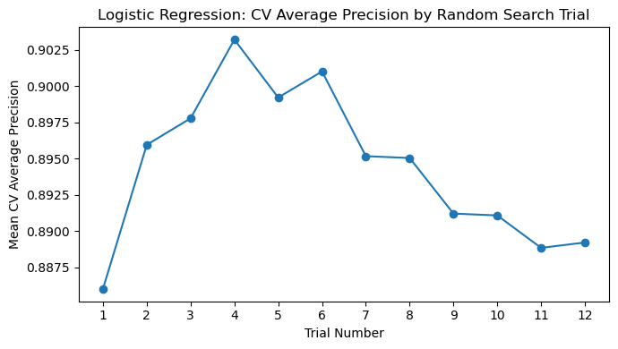

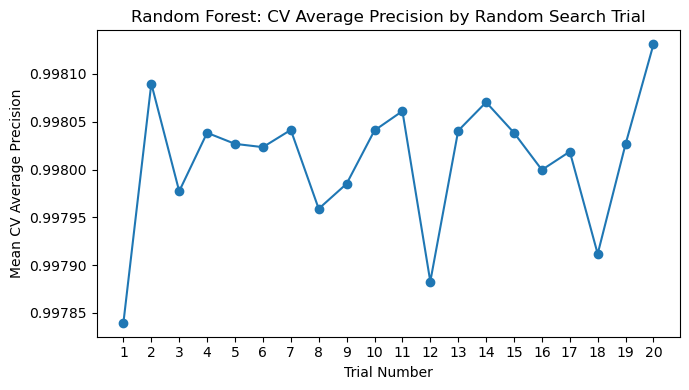

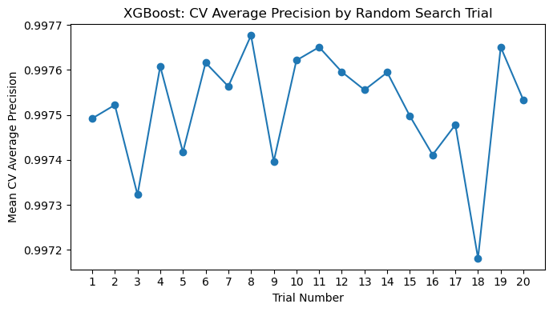

```python
for model_name in search_results_df["model"].unique():
    model_results = search_results_df[search_results_df["model"] == model_name].reset_index(drop=True)
    trial_numbers = range(1, len(model_results) + 1)

    plt.figure(figsize=(7, 4))
    plt.plot(trial_numbers, model_results["mean_test_score"], marker="o")
    plt.title(f"{model_name}: CV Average Precision by Random Search Trial")
    plt.xlabel("Trial Number")
    plt.ylabel("Mean CV Average Precision")
    plt.xticks(list(trial_numbers))
    plt.tight_layout()
    plt.show()
```

### Hyperparameter Value vs CV Score

These plots summarize the average CV score observed for each tested parameter value. Since this is randomized focused tuning, each value may still appear only a limited number of times.

```python
def plot_param_vs_score(search_results_df, model_name, param_col):
    model_results = search_results_df[search_results_df["model"] == model_name].copy()

    if param_col not in model_results.columns:
        print(f"{param_col} is not available for {model_name}. Skipping.")
        return

    model_results[param_col] = model_results[param_col].astype(str)
    plot_data = model_results.groupby(param_col)["mean_test_score"].mean()

    plt.figure(figsize=(7, 4))
    plt.plot(plot_data.index, plot_data.values, marker="o")
    plt.title(f"{model_name}: {param_col} vs CV Average Precision")
    plt.xlabel(param_col)
    plt.ylabel("Mean CV Average Precision")
    plt.xticks(rotation=45, ha="right")
    plt.tight_layout()
    plt.show()
```

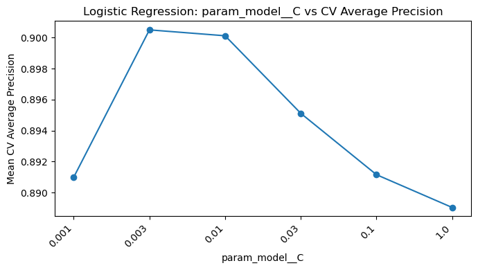

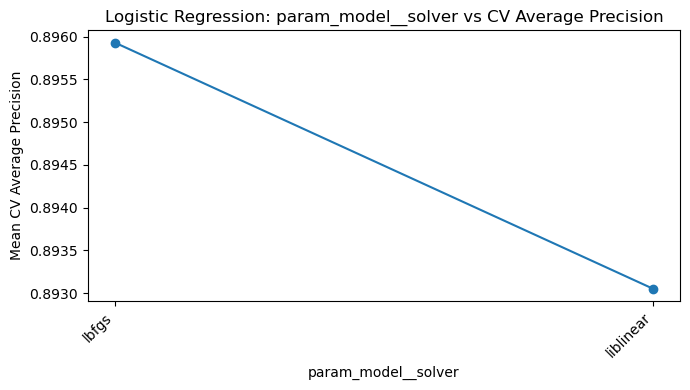

```python
plot_param_vs_score(search_results_df, "Logistic Regression", "param_model__C")
plot_param_vs_score(search_results_df, "Logistic Regression", "param_model__solver")
```

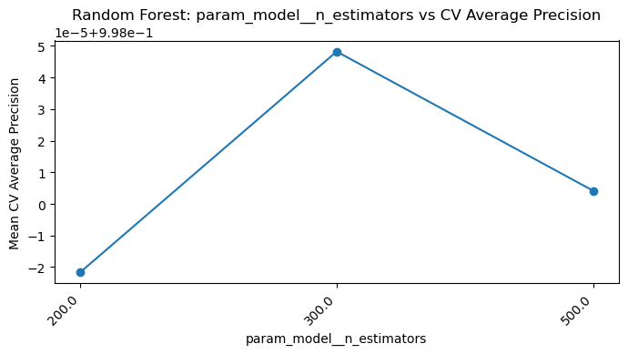

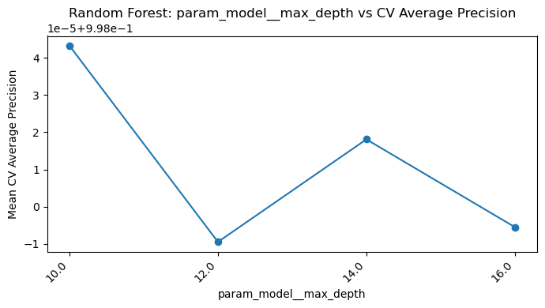

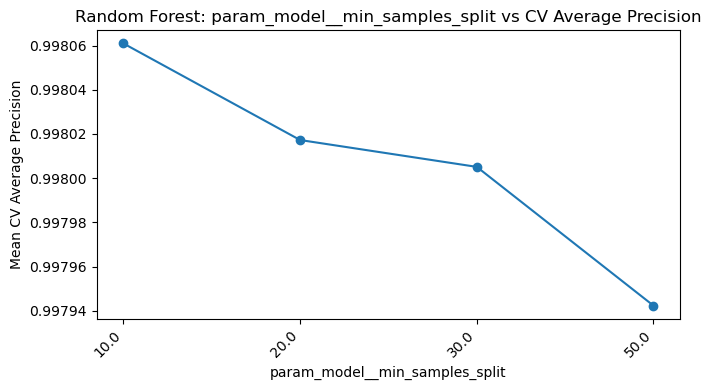

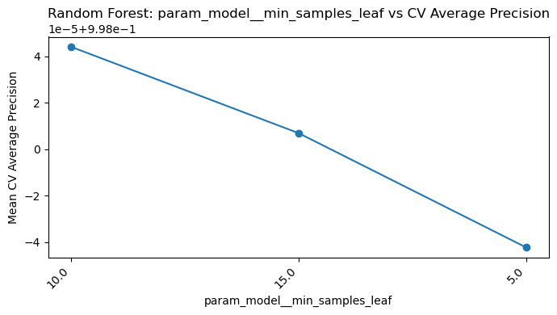

```python
plot_param_vs_score(search_results_df, "Random Forest", "param_model__n_estimators")
plot_param_vs_score(search_results_df, "Random Forest", "param_model__max_depth")
plot_param_vs_score(search_results_df, "Random Forest", "param_model__min_samples_split")
plot_param_vs_score(search_results_df, "Random Forest", "param_model__min_samples_leaf")
```

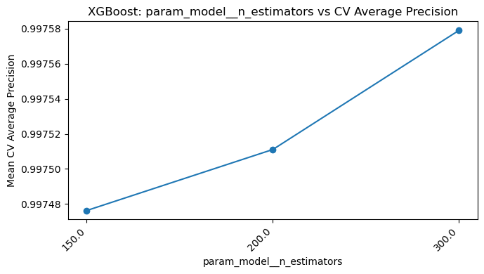

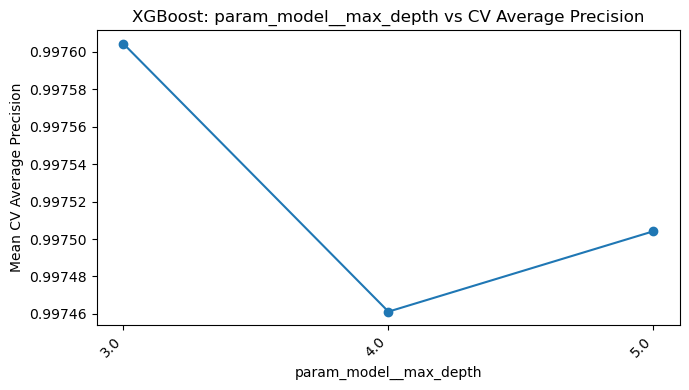

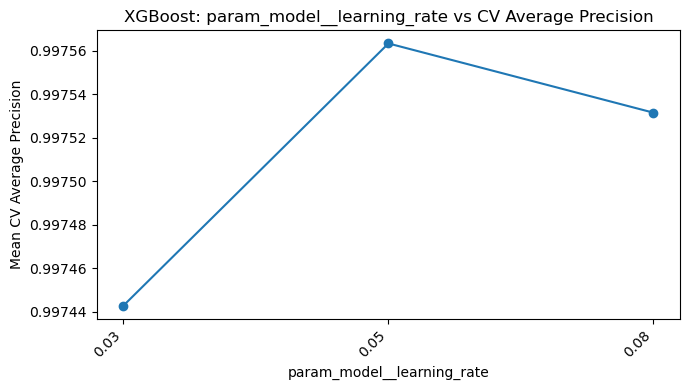

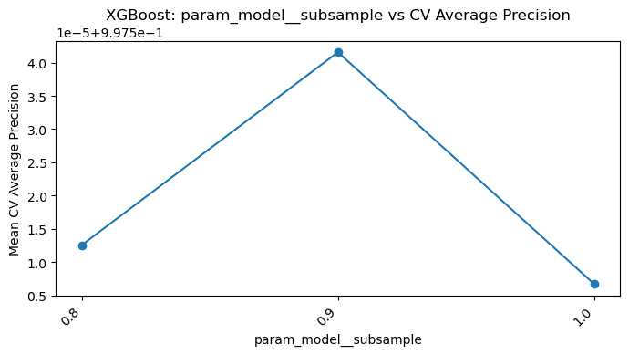

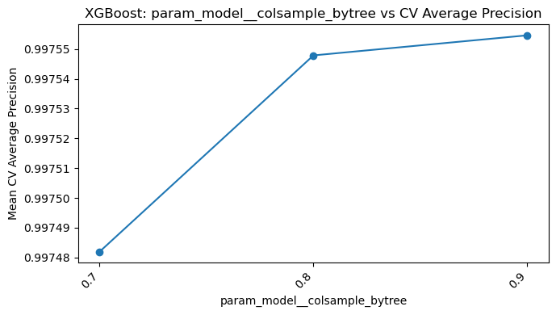

```python
plot_param_vs_score(search_results_df, "XGBoost", "param_model__n_estimators")
plot_param_vs_score(search_results_df, "XGBoost", "param_model__max_depth")
plot_param_vs_score(search_results_df, "XGBoost", "param_model__learning_rate")
plot_param_vs_score(search_results_df, "XGBoost", "param_model__subsample")
plot_param_vs_score(search_results_df, "XGBoost", "param_model__colsample_bytree")
```

### Boundary Check Summary

This check helps decide whether future tuning should expand candidate ranges. Boundary results are only diagnostic and do not change the current notebook selection logic.

```python
def check_best_params_on_boundary(tuned_searches, param_distributions):
    for model_name, search in tuned_searches.items():
        print(f"\n{model_name}")
        best_params = search.best_params_
        search_space = param_distributions.get(model_name, {})

        for param_name, best_value in best_params.items():
            candidates = search_space.get(param_name)

            if candidates is None:
                print(f"- {param_name}: {best_value} (not found in search space)")
                continue

            numeric_candidates = [value for value in candidates if isinstance(value, (int, float)) and value is not None]
            is_ordered_numeric = len(numeric_candidates) == len(candidates) and len(numeric_candidates) > 1

            if not is_ordered_numeric:
                print(f"- {param_name}: {best_value} (categorical / not ordered)")
                continue

            lower = min(numeric_candidates)
            upper = max(numeric_candidates)

            if best_value == lower:
                print(f"- {param_name}: {best_value} is at the lower tested boundary; future tuning could try lower values.")
            elif best_value == upper:
                print(f"- {param_name}: {best_value} is at the upper tested boundary; future tuning could try higher values.")
            else:
                print(f"- {param_name}: {best_value} is inside the candidate range; the current range appears reasonable for this focused tuning stage.")


check_best_params_on_boundary(tuned_searches, param_distributions)
```

```
Logistic Regression
- model__solver: lbfgs (categorical / not ordered)
- model__class_weight: balanced (categorical / not ordered)
- model__C: 0.003 is inside the candidate range; the current range appears reasonable for this focused tuning stage.

Random Forest
- model__n_estimators: 300 is inside the candidate range; the current range appears reasonable for this focused tuning stage.
- model__min_samples_split: 10 is at the lower tested boundary; future tuning could try lower values.
- model__min_samples_leaf: 5 is at the lower tested boundary; future tuning could try lower values.
- model__max_depth: 14 is inside the candidate range; the current range appears reasonable for this focused tuning stage.
- model__class_weight: balanced (categorical / not ordered)

XGBoost
- model__subsample: 0.8 is at the lower tested boundary; future tuning could try lower values.
- model__scale_pos_weight: 15.219155844155845 is at the lower tested boundary; future tuning could try lower values.
- model__n_estimators: 150 is at the lower tested boundary; future tuning could try lower values.
- model__max_depth: 3 is at the lower tested boundary; future tuning could try lower values.
- model__learning_rate: 0.05 is inside the candidate range; the current range appears reasonable for this focused tuning stage.
- model__colsample_bytree: 0.7 is at the lower tested boundary; future tuning could try lower values.
```

### Save Search Diagnostics

The combined cross-validation search results are saved for later review. Existing model comparison and final model outputs are unchanged.

```python
HYPERPARAMETER_SEARCH_RESULTS_PATH = REPORTS_DIR / "hyperparameter_search_results.csv"

REPORTS_DIR.mkdir(parents=True, exist_ok=True)
search_results_df.to_csv(HYPERPARAMETER_SEARCH_RESULTS_PATH, index=False)

print(f"Saved hyperparameter search diagnostics to: {HYPERPARAMETER_SEARCH_RESULTS_PATH}")
```

```
Saved hyperparameter search diagnostics to: d:\cs s1 26\基于深度学习的交易欺诈检测与智能风控系统\transaction-fraud-detection-system\reports\hyperparameter_search_results.csv
```

## 8. Evaluate Tuned Models on Validation Set

Each tuned model's `best_estimator_` is evaluated on the validation set only. The test set is still not used.

```python
tuned_results_df = evaluate_tuned_models(
    tuned_searches,
    X_val,
    y_val,
    threshold=0.5,
    sort_metric="pr_auc",
)

REPORTS_DIR.mkdir(parents=True, exist_ok=True)
tuned_results_df.to_csv(TUNED_RESULTS_PATH, index=False)
print(f"Saved tuned validation results to: {TUNED_RESULTS_PATH}")

tuned_results_df
```

```
Saved tuned validation results to: d:\cs s1 26\基于深度学习的交易欺诈检测与智能风控系统\transaction-fraud-detection-system\reports\tuned_model_comparison.csv
```

|  | model | accuracy | precision | recall | f1 | roc_auc | pr_auc | average_precision | tn | fp | fn | tp | best_params | best_cv_score |
| --- | --- | --- | --- | --- | --- | --- | --- | --- | --- | --- | --- | --- | --- | --- |
| 0 | Random Forest | 1.0000 | 0.9964 | 0.9982 | 0.9973 | 1.0000 | 0.9998 | 0.9998 | 1270876 | 6 | 3 | 1639 | {'model__n_estimators': 300, 'model__min_sampl... | 0.9981 |
| 1 | XGBoost | 1.0000 | 0.9939 | 0.9982 | 0.9960 | 1.0000 | 0.9994 | 0.9994 | 1270872 | 10 | 3 | 1639 | {'model__subsample': 0.8, 'model__scale_pos_we... | 0.9977 |
| 2 | Logistic Regression | 0.9536 | 0.0270 | 0.9957 | 0.0525 | 0.9968 | 0.6725 | 0.6725 | 1211872 | 59010 | 7 | 1635 | {'model__solver': 'lbfgs', 'model__class_weigh... | 0.9032 |

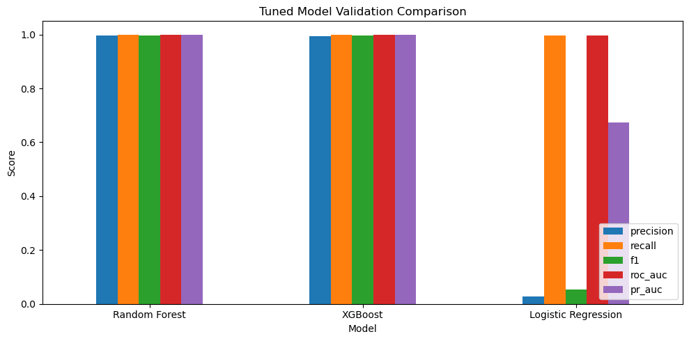

```python
plot_columns = ["precision", "recall", "f1", "roc_auc", "pr_auc"]

tuned_results_df.set_index("model")[plot_columns].plot(kind="bar", figsize=(10, 5))
plt.title("Tuned Model Validation Comparison")
plt.xlabel("Model")
plt.ylabel("Score")
plt.xticks(rotation=0)
plt.ylim(0, 1.05)
plt.legend(loc="lower right")
plt.tight_layout()
plt.show()
```

**Validation comparison guidance:** The selected model should be judged mainly by validation PR-AUC / average precision, while also considering recall, precision, F1-score, ROC-AUC, and confusion matrix values.

## 9. Select Best Tuned Supervised Model

The best tuned supervised model is selected using validation results only. The selected model name and best hyperparameters will be used in the final refit step. The test set is still untouched.

```python
best_model_name = select_best_tuned_model(tuned_results_df, metric="pr_auc")
best_estimator = get_best_estimator(tuned_searches, best_model_name)
best_params = tuned_searches[best_model_name].best_params_

print(f"Selected best tuned supervised model: {best_model_name}")
print("Best hyperparameters:")
print(best_params)
```

```
Selected best tuned supervised model: Random Forest
Best hyperparameters:
{'model__n_estimators': 300, 'model__min_samples_split': 10, 'model__min_samples_leaf': 5, 'model__max_depth': 14, 'model__class_weight': 'balanced'}
```

## Final Supervised Model Refit and Holdout Evaluation

The final supervised model is selected using validation performance after tuning. After selection, we refit that selected tuned pipeline using train + validation data only. The test set remains untouched until the final holdout evaluation.

This refitted model is saved for later integration with the Autoencoder and risk scoring modules. It is the final supervised ML model, not the final integrated risk system.

### Combine Train and Validation Data

We combine the original full training split (`X_train_full`, `y_train_full`) with the untouched validation set (`X_val`, `y_val`). Then we apply training-only sampling again to the combined train + validation data. The test set is not included.

```python
X_trainval_final = pd.concat([X_train_full, X_val], axis=0)
y_trainval_final = pd.concat([y_train_full, y_val], axis=0)

print(f"Combined train + validation X shape: {X_trainval_final.shape}")
print(f"Combined train + validation y shape: {y_trainval_final.shape}")

pd.DataFrame({
    "count": y_trainval_final.value_counts().sort_index(),
    "percent": y_trainval_final.value_counts(normalize=True).sort_index() * 100,
})
```

```
Combined train + validation X shape: (5090096, 16)
Combined train + validation y shape: (5090096,)
```

| isFraud | count | percent |
| --- | --- | --- |
| 0 | 5083526 | 99.8709 |
| 1 | 6570 | 0.1291 |

```python
X_trainval_sampled, y_trainval_sampled = sample_training_data(
    X_trainval_final,
    y_trainval_final,
    n_normal=300_000,
    random_state=RANDOM_STATE,
)

print(f"Sampled final training X shape: {X_trainval_sampled.shape}")
print(f"Sampled final training y shape: {y_trainval_sampled.shape}")

pd.DataFrame({
    "count": y_trainval_sampled.value_counts().sort_index(),
    "percent": y_trainval_sampled.value_counts(normalize=True).sort_index() * 100,
})
```

```
Sampled final training X shape: (306570, 16)
Sampled final training y shape: (306570,)
```

| isFraud | count | percent |
| --- | --- | --- |
| 0 | 300000 | 97.8569 |
| 1 | 6570 | 2.1431 |

### Refit Selected Tuned Model

We clone the selected best estimator before refitting. This creates a fresh pipeline with the same best hyperparameters, then fits it on the sampled train + validation data.

```python
final_supervised_model = clone(best_estimator)
final_supervised_model.fit(X_trainval_sampled, y_trainval_sampled)

print(f"Refitted final supervised model: {best_model_name}")
print("Best hyperparameters used for refit:")
print(best_params)
```

```
Refitted final supervised model: Random Forest
Best hyperparameters used for refit:
{'model__n_estimators': 300, 'model__min_samples_split': 10, 'model__min_samples_leaf': 5, 'model__max_depth': 14, 'model__class_weight': 'balanced'}
```

### Final Holdout Test Evaluation

The untouched test set is used once here for final supervised holdout evaluation. It was not used for tuning or model selection.

```python
final_test_metrics = evaluate_binary_classifier(
    final_supervised_model,
    X_test,
    y_test,
    model_name=f"Final Supervised Model ({best_model_name})",
)

final_test_metrics_df = pd.DataFrame([final_test_metrics])
final_test_metrics_df
```

|  | model | accuracy | precision | recall | f1 | roc_auc | pr_auc | average_precision | tn | fp | fn | tp |
| --- | --- | --- | --- | --- | --- | --- | --- | --- | --- | --- | --- | --- |
| 0 | Final Supervised Model (Random Forest) | 1.0000 | 0.9964 | 0.9976 | 0.9970 | 1.0000 | 0.9988 | 0.9988 | 1270875 | 6 | 4 | 1639 |

```python
confusion_values = final_test_metrics_df[["tn", "fp", "fn", "tp"]]
print("Confusion matrix values:")
print(confusion_values.to_string(index=False))
```

```
Confusion matrix values:
     tn  fp  fn   tp
1270875   6   4 1639
```

### Save Final Supervised Outputs

The refitted final supervised model pipeline and final holdout test metrics are saved for later project stages.

```python
FINAL_SUPERVISED_MODEL_PATH.parent.mkdir(parents=True, exist_ok=True)
REPORTS_DIR.mkdir(parents=True, exist_ok=True)

joblib.dump(final_supervised_model, FINAL_SUPERVISED_MODEL_PATH)
final_test_metrics_df.to_csv(FINAL_TEST_METRICS_PATH, index=False)

print(f"Saved final supervised model pipeline to: {FINAL_SUPERVISED_MODEL_PATH}")
print(f"Saved final supervised holdout test metrics to: {FINAL_TEST_METRICS_PATH}")
```

```
Saved final supervised model pipeline to: d:\cs s1 26\基于深度学习的交易欺诈检测与智能风控系统\transaction-fraud-detection-system\models\ml\final_supervised_model.pkl
Saved final supervised holdout test metrics to: d:\cs s1 26\基于深度学习的交易欺诈检测与智能风控系统\transaction-fraud-detection-system\reports\final_supervised_test_evaluation.csv
```

## 10. Final Notes

- Hyperparameter tuning used a focused second-round randomized search with `n_iter=20` and `cv=5`.
- The validation set was used for tuned model comparison and final supervised model selection.
- The final refit used train + validation data only.
- The test set was used only once at the end for holdout evaluation.
- The refitted supervised model is saved for later integration with Autoencoder and risk scoring modules.
- This model is the final supervised ML model, not the final integrated risk system.
- This PaySim V1 system remains a post-transaction fraud detection and risk monitoring system because it uses balance-related fields such as `newbalanceOrig` and `newbalanceDest`.

### Next Step

Build the Autoencoder anomaly detection module in `04_financial_autoencoder_experiment.ipynb` as a supplementary risk signal. Integrated risk scoring will be developed later in `05_financial_risk_scoring_and_dashboard_prep.ipynb` after both supervised ML and Autoencoder signals are available.